# R Notebook

First let’s load the survey data.

```r
library(dplyr)
library(ggplot2)
library(rstatix)
load("~/Dropbox (University of Oregon)/UO-SAN Lab/Berkman Lab/Devaluation/analysis_files/data/scored_data_coded.RData")
```

Now let’s take a look at the scores on these scales. We want FCI and FFQ

```r
print(table(scored$survey_name))
```

```
DEV Session 0 Surveys DEV Session 1 Surveys DEV Session 2 Surveys DEV Session 3 Surveys DEV Session 4 Surveys
                 4950                  5152                  4978                  3472                  3164
```

```r
print(table(scored$scale_name))
```

```
  ACES    BFI BIS-11   BSCS    EDM    FCI    FFQ    IMI    NCS   PLAN
   655    990    644    533    161   6877   7406    655   3135    660
```

```r
scored %>% filter(scale_name=="FCI") %>% .$scored_scale %>% table
```

```
.
cancer_preventing  cancer_promoting             dairy    empty_calories        fried_food             fruit            grains         olive_oil   processed_meats
              529               529               529               529               529               529               529               529               529
          protein         red_meats      sugary_foods        vegetables
              529               529               529               529
```

```r
scored %>% filter(scale_name=="FFQ") %>% .$scored_scale %>% table
```

```
.
cancer_preventing  cancer_promoting             dairy    empty_calories        fried_food            fruits            grains              meat   processed_meats
              529               529               529               529               529               529               529               529               529
          protein          red_meat             soups      sugary_foods        vegetables
              529               529               529               529               529
```

## Compare Session 2 and Session 1

Better to not use percent; use differences instead.

https://www.researchgate.net/publication/11881571_The_use_of_percentage_change_from_baseline_as_an_outcome_in_a_controlled_trial_is_statistically_inefficient_A_simulation_study

ANCOVA with baseline score as a covariate is even better; I suspect a linear model would do the same thing

Confirmed: https://stats.stackexchange.com/questions/14246/when-should-one-use-multiple-regression-with-dummy-coding-vs-ancova#:~:text=ANCOVA%20and%20multiple%20linear%20regression,one%20of%20the%20independent%20variables.

Some practical guidelines for performing ANCOVA: https://www.datanovia.com/en/lessons/ancova-in-r/

```r
promote_minus_prevent <- scored %>%
  #filter for FFQ
  filter(scale_name %in% c("FFQ","FCI")) %>%
  #filter for the two cols we're interested in
  filter(scored_scale %in% c("cancer_promoting","cancer_preventing")) %>%
  #throw it out wide
  select(subid,scored_scale,score,survey_name,scale_name) %>% tidyr::pivot_wider(names_from = scored_scale,values_from = score) %>%
  #create a composite measure
  mutate("cancer_promoting_minus_preventing"=cancer_promoting-cancer_preventing) %>%
  #wide across the surveys so that we can compare the surveys
  select(scale_name,survey_name,subid,cancer_promoting_minus_preventing) %>%
  tidyr::spread(survey_name,cancer_promoting_minus_preventing)

pmp_fci <- promote_minus_prevent %>% filter(scale_name=="FCI") %>% select(-scale_name)
pmp_ffq <- promote_minus_prevent %>% filter(scale_name=="FFQ") %>% select(-scale_name)
```

```r
#we are most interested in cancer-promoting foods; this score has hopefully decreased.
#but...we could design a composite score...that measures both together. That might be even better...
#I think we are interested in the intercept.
model_session_2_ffq <- lm(`DEV Session 2 Surveys`~`DEV Session 1 Surveys`, pmp_ffq)
summary(model_session_2_ffq)
```

```
Call:
lm(formula = `DEV Session 2 Surveys` ~ `DEV Session 1 Surveys`,
    data = pmp_ffq)

Residuals:
     Min       1Q   Median       3Q      Max
-0.74271 -0.20288  0.01641  0.22338  0.83247

Coefficients:
                        Estimate Std. Error t value Pr(>|t|)
(Intercept)             -0.18653    0.03376  -5.526 1.78e-07 ***
`DEV Session 1 Surveys`  0.72123    0.05934  12.155  < 2e-16 ***
---
Signif. codes:  0 ‘***’ 0.001 ‘**’ 0.01 ‘*’ 0.05 ‘.’ 0.1 ‘ ’ 1

Residual standard error: 0.3145 on 127 degrees of freedom
  (34 observations deleted due to missingness)
Multiple R-squared:  0.5377,    Adjusted R-squared:  0.5341
F-statistic: 147.7 on 1 and 127 DF,  p-value: < 2.2e-16
```

Let’s see what it looks like as a simple subtraction. Then let’s test the assupmtions of the ANCOVA.

```r
t.test(pmp_ffq$`DEV Session 2 Surveys`-pmp_ffq$`DEV Session 1 Surveys`)
```

```
    One Sample t-test

data:  pmp_ffq$`DEV Session 2 Surveys` - pmp_ffq$`DEV Session 1 Surveys`
t = -3.2066, df = 128, p-value = 0.001696
alternative hypothesis: true mean is not equal to 0
95 percent confidence interval:
 -0.15494468 -0.03669317
sample estimates:
  mean of x
-0.09581892
```

## Check assumptions for ANCOVA

### Linearity

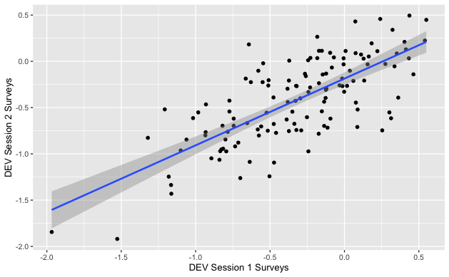

```r
ggplot(pmp_ffq,aes(`DEV Session 1 Surveys`,`DEV Session 2 Surveys`))+geom_point()+geom_smooth(method="lm")
```

### Homogeneity of regression slopes

(No grouping variable yet)

### Normality of residuals

```r
library(broom)
model.metrics<- augment(model_session_2_ffq) %>% select(-.hat, -.sigma, -.fitted) # Remove details
head(model.metrics, 3)
```

| .rownames | DEV Session 2 Surveys | DEV Session 1 Surveys | .resid | .cooksd | .std.resid |
| --- | --- | --- | --- | --- | --- |
| 1 | 0.45769231 | 0.240384615 | 0.4708489 | 0.022306301 | 1.5117316 |
| 2 | -0.32884615 | -0.001923077 | -0.1409312 | 0.001179284 | -0.4507219 |
| 3 | -0.02115385 | -0.546153846 | 0.5592740 | 0.015290485 | 1.7868559 |

Test for non-normality of residuals

```r
library(rstatix)
shapiro_test(model.metrics$.resid)
```

| variable | statistic | p.value |
| --- | --- | --- |
| model.metrics$.resid | 0.9920334 | 0.6772288 |

### homogenety of variances

(not for a single group)

### outliers

```r
model.metrics %>%
  filter(abs(.std.resid) > 3) %>%
  as.data.frame()
```

| .rownames | DEV Session 2 Surveys | DEV Session 1 Surveys | .resid | .cooksd | .std.resid |
| --- | --- | --- | --- | --- | --- |

## Compare the conditions….

```r
participants_with_promote_prevent <- merge(ppt_list_clean,pmp_ffq,by.x = "subid",by.y="subid")
participants_with_promote_prevent$s2_minus_s1 <- participants_with_promote_prevent$`DEV Session 2 Surveys`-participants_with_promote_prevent$`DEV Session 1 Surveys`
```

First do a qualitative look at the three conditions…

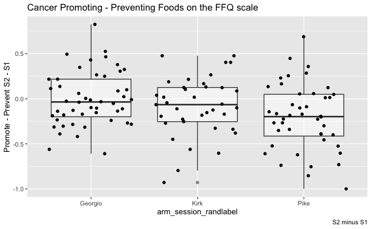

```r
ggplot(participants_with_promote_prevent,aes(x=arm_session_randlabel,y=s2_minus_s1))+geom_boxplot(alpha=0.5)+geom_point(position="jitter")+
  labs(y="Promote - Prevent S2 - S1",title = "Cancer Promoting - Preventing Foods on the FFQ scale",caption="S2 minus S1")
```

```r
NA
NA
```

Take the HIGHEST session and make it the baseline

```r
arm_comparison <- participants_with_promote_prevent %>% group_by(arm_session_randlabel) %>% summarise(mean_s2_minus_s1 = mean(s2_minus_s1,na.rm=TRUE))
arm_comparison <- arm_comparison %>% arrange(-mean_s2_minus_s1)


#now do the levelling, in order from lowest to highest.
participants_with_promote_prevent$arm_session_randlabel <- factor(participants_with_promote_prevent$arm_session_randlabel,levels=arm_comparison$arm_session_randlabel)
```

```r
model_session_2_conditions <- lm(`DEV Session 2 Surveys`~`DEV Session 1 Surveys`+arm_session_randlabel, participants_with_promote_prevent)
model_session_2_noconditions <- lm(`DEV Session 2 Surveys`~`DEV Session 1 Surveys`, participants_with_promote_prevent)
summary(model_session_2_conditions)
```

```
Call:
lm(formula = `DEV Session 2 Surveys` ~ `DEV Session 1 Surveys` +
    arm_session_randlabel, data = participants_with_promote_prevent)

Residuals:
     Min       1Q   Median       3Q      Max
-0.65880 -0.20652 -0.02082  0.23556  0.74808

Coefficients:
                          Estimate Std. Error t value Pr(>|t|)
(Intercept)               -0.09505    0.04858  -1.957  0.05260 .
`DEV Session 1 Surveys`    0.73226    0.05847  12.524  < 2e-16 ***
arm_session_randlabelKirk -0.09451    0.06740  -1.402  0.16331
arm_session_randlabelPike -0.17819    0.06439  -2.767  0.00651 **
---
Signif. codes:  0 ‘***’ 0.001 ‘**’ 0.01 ‘*’ 0.05 ‘.’ 0.1 ‘ ’ 1

Residual standard error: 0.3077 on 125 degrees of freedom
  (34 observations deleted due to missingness)
Multiple R-squared:  0.5645,    Adjusted R-squared:  0.5541
F-statistic: 54.01 on 3 and 125 DF,  p-value: < 2.2e-16
```

There does appear to be differences between the conditions…let’s take a look at the residuals of the model without conditions, but with the conditions classifying…

```r
participants_with_promote_prevent[as.integer(names(model_session_2_noconditions$residuals)),"residuals"] <- model_session_2_noconditions$residuals
```

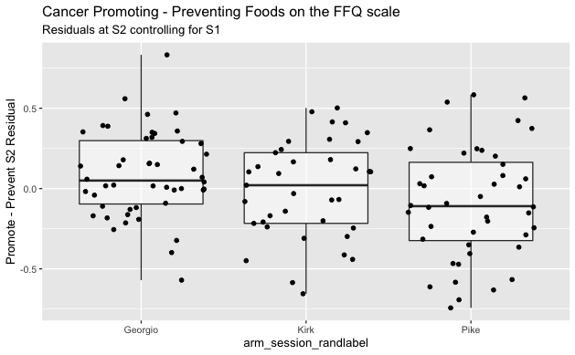

```r
ggplot(participants_with_promote_prevent,aes(x=arm_session_randlabel,y=residuals))+geom_boxplot(alpha=0.5)+geom_point(position="jitter")+
  labs(y="Promote - Prevent S2 Residual",title = "Cancer Promoting - Preventing Foods on the FFQ scale",subtitle="Residuals at S2 controlling for S1")
```

## Check assumptions for ANCOVA

### Linearity

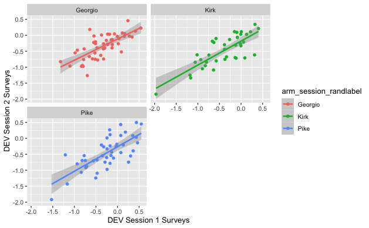

```r
ggplot(participants_with_promote_prevent,aes(`DEV Session 1 Surveys`,`DEV Session 2 Surveys`,group=arm_session_randlabel,color=arm_session_randlabel))+
  geom_point()+geom_smooth(method="lm")+facet_wrap(~arm_session_randlabel,nrow = 2)
```

### Homogeneity of regression slopes

```r
anova_test(participants_with_promote_prevent,`DEV Session 2 Surveys`~arm_session_randlabel*`DEV Session 1 Surveys`)
```

```
NA detected in rows: 4,7,16,22,28,29,30,39,42,46,54,58,66,67,73,79,80,83,87,94,100,105,106,109,132,134,137,145,146,147,152,157,158,162.
Removing this rows before the analysis.Coefficient covariances computed by hccm()
```

```
ANOVA Table (type II tests)

                                         Effect DFn DFd       F        p p<.05   ges
1                         arm_session_randlabel   2 123   3.800 2.50e-02     * 0.058
2                       `DEV Session 1 Surveys`   1 123 155.045 1.57e-23     * 0.558
3 arm_session_randlabel:`DEV Session 1 Surveys`   2 123   0.285 7.53e-01       0.005
```

Great: no interaction observed.

### Normality of residuals

```r
library(broom)
model.metrics<- augment(model_session_2_conditions) %>% select(-.hat, -.sigma, -.fitted) # Remove details
head(model.metrics, 3)
```

| .rownames | DEV Session 2 Surveys | DEV Session 1 Surveys | arm_session_randlabel | .resid | .cooksd | .std.resid |
| --- | --- | --- | --- | --- | --- | --- |
| 1 | 0.45769231 | 0.240384615 | Georgio | 0.3767207 | 0.013165820 | 1.2450377 |
| 2 | -0.32884615 | -0.001923077 | Kirk | -0.1378785 | 0.001748446 | -0.4556171 |
| 3 | -0.02115385 | -0.546153846 | Georgio | 0.4738275 | 0.013909375 | 1.5575864 |

Test for non-normality of residuals

```r
library(rstatix)
shapiro_test(model.metrics$.resid)
```

| variable | statistic | p.value |
| --- | --- | --- |
| model.metrics$.resid | 0.99251 | 0.7253178 |

### homogenety of variances

```r
#model.metrics %>% levene_test(.resid~arm_session_randlabel)
```

### outliers

```r
model.metrics %>%
  filter(abs(.std.resid) > 3) %>%
  as.data.frame()
```

| .rownames | DEV Session 2 Surveys | DEV Session 1 Surveys | arm_session_randlabel | .resid | .cooksd | .std.resid |
| --- | --- | --- | --- | --- | --- | --- |

# allow for date started

OK great - we can do this all again for the other inventory we are measuring. then we have to make a decision to pull back the data and inspect which groups are which!

Also–do we want to control for other factors, like Month Began?

standard way to do this in this field might be just try to add a linear trend, then quadratic, then cubic, and so on until it doesn’t improve fit.

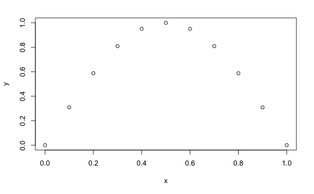

```r
#adding periodicity into a linear model
x <- seq(from=0,to=1,by=0.1)
y <- sin(x*pi)
plot(x,y)
```

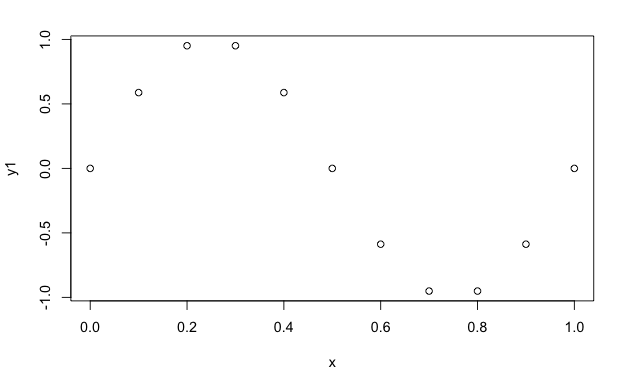

```r
y1 <- sin(x*2*pi)
plot(x,y1)
```

```r
library(lubridate)
min_date <- min(participants_with_promote_prevent$date_0)
participants_with_promote_prevent$date_linear <- as.numeric(as.POSIXct(participants_with_promote_prevent$date_0))
# summary(lm(`DEV Session 1 Surveys`~ date_linear, participants_with_promote_prevent))
# summary(lm(`DEV Session 1 Surveys`~ I(date_linear^3), participants_with_promote_prevent))
#no evidence of any date effect here. we could try for a simple seasonality (period of 4 with 2)
participants_with_promote_prevent <-
  participants_with_promote_prevent %>% #select(date_linear,date_0) %>%
  mutate(date_years_linear=as.numeric(difftime(date_0,min(min_date),unit="days"))/365) %>%
  mutate(day_in_year=yday(date_0)) %>%
  mutate(date_years_period1 = sin(date_years_linear*pi)) %>%
  mutate(date_years_period2 = sin(date_years_linear*2*pi)) %>%
  mutate(year_as_factor = as.factor(year(date_0)))



summary(lm(`DEV Session 1 Surveys`~ date_years_linear + date_years_period1 + date_years_period2, participants_with_promote_prevent))
```

```
Call:
lm(formula = `DEV Session 1 Surveys` ~ date_years_linear + date_years_period1 +
    date_years_period2, data = participants_with_promote_prevent)

Residuals:
     Min       1Q   Median       3Q      Max
-1.57604 -0.34849  0.03991  0.35764  0.88825

Coefficients:
                   Estimate Std. Error t value Pr(>|t|)
(Intercept)        -0.23455    0.10060  -2.332    0.021 *
date_years_linear  -0.07292    0.08660  -0.842    0.401
date_years_period1 -0.08524    0.07065  -1.207    0.229
date_years_period2 -0.06971    0.06287  -1.109    0.269
---
Signif. codes:  0 ‘***’ 0.001 ‘**’ 0.01 ‘*’ 0.05 ‘.’ 0.1 ‘ ’ 1

Residual standard error: 0.4693 on 156 degrees of freedom
  (3 observations deleted due to missingness)
Multiple R-squared:  0.0117,    Adjusted R-squared:  -0.007301
F-statistic: 0.6159 on 3 and 156 DF,  p-value: 0.6057
```

```r
#no sign that any of this makes a difference...
```

But there is an effect of time on the variable we are trying to predict…

we should probably control for this.

```r
summary(lm(s2_minus_s1~ date_years_linear + date_years_period1, participants_with_promote_prevent))
```

```
Call:
lm(formula = s2_minus_s1 ~ date_years_linear + date_years_period1,
    data = participants_with_promote_prevent)

Residuals:
     Min       1Q   Median       3Q      Max
-0.81898 -0.18080  0.02174  0.22152  0.89945

Coefficients:
                   Estimate Std. Error t value Pr(>|t|)
(Intercept)        -0.34304    0.08290  -4.138 6.35e-05 ***
date_years_linear   0.25528    0.08122   3.143  0.00209 **
date_years_period1  0.15933    0.05680   2.805  0.00583 **
---
Signif. codes:  0 ‘***’ 0.001 ‘**’ 0.01 ‘*’ 0.05 ‘.’ 0.1 ‘ ’ 1

Residual standard error: 0.3286 on 126 degrees of freedom
  (34 observations deleted due to missingness)
Multiple R-squared:  0.0772,    Adjusted R-squared:  0.06255
F-statistic:  5.27 on 2 and 126 DF,  p-value: 0.006336
```

```r
summary(lm(s2_minus_s1~ year_as_factor, participants_with_promote_prevent)) #close enough to significance to consider adding it in.
```

```
Call:
lm(formula = s2_minus_s1 ~ year_as_factor, data = participants_with_promote_prevent)

Residuals:
     Min       1Q   Median       3Q      Max
-0.89271 -0.19758 -0.00425  0.21114  0.94088

Coefficients:
                    Estimate Std. Error t value Pr(>|t|)
(Intercept)        -0.107290   0.051375  -2.088   0.0388 *
year_as_factor2019 -0.008589   0.064286  -0.134   0.8939
year_as_factor2020  0.213251   0.118274   1.803   0.0738 .
---
Signif. codes:  0 ‘***’ 0.001 ‘**’ 0.01 ‘*’ 0.05 ‘.’ 0.1 ‘ ’ 1

Residual standard error: 0.3369 on 126 degrees of freedom
  (34 observations deleted due to missingness)
Multiple R-squared:  0.03007,   Adjusted R-squared:  0.01468
F-statistic: 1.953 on 2 and 126 DF,  p-value: 0.1461
```

```r
summary(lm(s2_minus_s1~ day_in_year*year_as_factor + date_years_period1*year_as_factor, participants_with_promote_prevent))
```

```
Call:
lm(formula = s2_minus_s1 ~ day_in_year * year_as_factor + date_years_period1 *
    year_as_factor, data = participants_with_promote_prevent)

Residuals:
     Min       1Q   Median       3Q      Max
-0.80950 -0.18540  0.00904  0.20248  0.93285

Coefficients:
                                        Estimate Std. Error t value Pr(>|t|)
(Intercept)                           -0.5419958  0.2909155  -1.863   0.0649 .
day_in_year                            0.0016459  0.0027116   0.607   0.5450
year_as_factor2019                     0.3414952  0.4595035   0.743   0.4588
year_as_factor2020                     0.4542874  1.5728611   0.289   0.7732
date_years_period1                     0.0416147  0.5682226   0.073   0.9417
day_in_year:year_as_factor2019        -0.0009351  0.0039152  -0.239   0.8116
day_in_year:year_as_factor2020         0.0003408  0.0105211   0.032   0.9742
year_as_factor2019:date_years_period1  0.0801511  0.6982620   0.115   0.9088
year_as_factor2020:date_years_period1 -0.1197505  1.8570638  -0.064   0.9487
---
Signif. codes:  0 ‘***’ 0.001 ‘**’ 0.01 ‘*’ 0.05 ‘.’ 0.1 ‘ ’ 1

Residual standard error: 0.335 on 120 degrees of freedom
  (34 observations deleted due to missingness)
Multiple R-squared:  0.08683,   Adjusted R-squared:  0.02595
F-statistic: 1.426 on 8 and 120 DF,  p-value: 0.1924
```

```r
model_session_2_m2 <- lm(`DEV Session 2 Surveys`~`DEV Session 1 Surveys`+arm_session_randlabel + day_in_year*year_as_factor + date_years_period1*year_as_factor, participants_with_promote_prevent)
summary(model_session_2_m2)
```

```
Call:
lm(formula = `DEV Session 2 Surveys` ~ `DEV Session 1 Surveys` +
    arm_session_randlabel + day_in_year * year_as_factor + date_years_period1 *
    year_as_factor, data = participants_with_promote_prevent)

Residuals:
     Min       1Q   Median       3Q      Max
-0.61269 -0.17486 -0.00615  0.18789  0.76098

Coefficients:
                                       Estimate Std. Error t value Pr(>|t|)
(Intercept)                           -0.689607   0.269334  -2.560   0.0117 *
`DEV Session 1 Surveys`                0.730053   0.059303  12.311   <2e-16 ***
arm_session_randlabelKirk             -0.120578   0.068494  -1.760   0.0810 .
arm_session_randlabelPike             -0.171280   0.066136  -2.590   0.0108 *
day_in_year                            0.002959   0.002492   1.187   0.2375
year_as_factor2019                     0.569060   0.417853   1.362   0.1759
year_as_factor2020                     0.940834   1.439398   0.654   0.5146
date_years_period1                    -0.197450   0.526564  -0.375   0.7084
day_in_year:year_as_factor2019        -0.002725   0.003590  -0.759   0.4494
day_in_year:year_as_factor2020        -0.003524   0.009608  -0.367   0.7144
year_as_factor2019:date_years_period1  0.255933   0.638065   0.401   0.6891
year_as_factor2020:date_years_period1  0.513147   1.691978   0.303   0.7622
---
Signif. codes:  0 ‘***’ 0.001 ‘**’ 0.01 ‘*’ 0.05 ‘.’ 0.1 ‘ ’ 1

Residual standard error: 0.302 on 117 degrees of freedom
  (34 observations deleted due to missingness)
Multiple R-squared:  0.6072,    Adjusted R-squared:  0.5703
F-statistic: 16.44 on 11 and 117 DF,  p-value: < 2.2e-16
```

Ideally we should look to test the interaction between group and the linear features but we’ll leave that for now.

We might also be raising too high a bar here: this is a lot of nuisance factors to throw in and it might be overly conservative.

Because of COVID, it’s probably important to add in some seasonal variance, because things get so unpredictable.